# IT5100F_project_assnmt

- Table of Contents
- Task 1: Problem definition
  - Objectives for the Data Pipeline:
    - Measurement of Success:
    - Use Cases for the Data Pipeline:
- Task 2: Data collection/curation
- Task 3: Data preparation
  - Initial Loading of data
    - Data cleaning and handling null values
- Task 4: Exploratory data analysis and visualization
  - Understanding the data
  - Floor size over time Trend Analysis:
    - Town affect on resale price over time
    - Investigating flat_type's effect on resale price
- Task 5: Modeling and visualization
  - Objective 1: Identify Location and Room Type with Highest Investment Return
  - Objective 2-1: Using Linear Regression to Predict Future Price Growth
  - Objective 2-2: Using Machine Learning to Predict Future Price Growth
- Task 6: Report insights and conclusions

View this notebook in:  
| [Link to Github pages](https://antheajfw.github.io/it5100f-pg/) | [Link to notebook](https://github.com/AntheaJFW/it5100f-pg/blob/main/IT5100F_project_assnmt.ipynb)

# Task 1: Problem definition

## Objectives for the Data Pipeline:

**Objective 1: Identify Location and Room-Type with Highest Investment Return:**  
This involves analyzing historical resale price data to determine which locations and types of rooms (e.g., 4-room, 5-room, etc.) have shown the highest return on investment over the past years. It aims to provide insights for potential property investors or homeowners looking to maximize their returns.

**Objective 2: Using Machine Learning to Predict Future Price Growth:**  
This objective involves building predictive models using machine learning algorithms on historical resale price data to forecast future price growth. By leveraging past trends and patterns, the goal is to provide stakeholders with insights into potential future price movements, aiding in decision-making processes related to property investment.

### Measurement of Success:

The success of the data pipeline can be measured based on the following criteria:

- **Accuracy of Predictions:** For Objective 1, success can be measured by the accuracy of identifying locations and room types with the highest investment return based on historical data analysis. For Objective 2, success can be measured by the accuracy of the machine learning models in predicting future price growth.
- **Return on Investment (ROI):** Success can also be evaluated based on the ROI achieved by stakeholders who utilize the insights provided by the data pipeline. Higher ROI indicates the effectiveness of the insights generated.

### Use Cases for the Data Pipeline:

The data pipeline will serve various use cases including:

- **Reporting:** Generating reports on historical resale price trends, identifying locations and room types with the highest investment return, and providing summaries of machine learning predictions for future price growth.
- **Analytics:** Performing in-depth analysis of historical resale price data to uncover trends, patterns, and correlations that can inform decision-making related to property investment.
- **Machine Learning:** Developing and deploying machine learning models to predict future price growth based on historical data, enabling stakeholders to make informed decisions about property investment strategies.

# Task 2: Data collection/curation

```python
import re
import datetime
import warnings
import pandas as pd
import seaborn as sns

from matplotlib import rcParams
import matplotlib.pyplot as plt
from pathlib import Path

warnings.filterwarnings('ignore')
# sns.set_theme()

# figure size in inches
rcParams['figure.figsize'] = 11.7,5.27
```

The primary dataset required for this analysis is the HDB resale price data, which contains information about the resale prices of HDB flats in different locations and with various room types over past years. This dataset can be downloaded from data.gov.sg, specifically from these links:

1. [Resale flat prices based on registration date from Jan-2017 onwards](https://beta.data.gov.sg/datasets/d_8b84c4ee58e3cfc0ece0d773c8ca6abc/view)
2. [Resale Flat Prices (Based on Registration Date), From Jan 2015 to Dec 2016](https://beta.data.gov.sg/datasets/d_ea9ed51da2787afaf8e51f827c304208/view)
3. [Resale Flat Prices (Based on Registration Date), From Mar 2012 to Dec 2014](https://beta.data.gov.sg/datasets/d_2d5ff9ea31397b66239f245f57751537/view)

The 3 csv files are concatenated together to form the starting dataset.

To work towards to the objectives defined in Task 1, we intend to proceed with the following steps:

1. Data Cleaning and Preparation: Preprocess the data to handle missing values, outliers, and inconsistencies. Ensure proper formatting of variables such as location, room type, and price.
2. Exploratory Data Analysis (EDA):
   - Conduct EDA on the integrated dataset to understand the distributions, correlations, and patterns within the data.
   - Identify potential features that correlate with investment return and price growth, such as location, room type, economic indicators, and demographic factors.
3. Model Development:
   - Identify Features: Select relevant features for modeling based on insights from EDA and domain knowledge.
   - Machine Learning Algorithms: Choose appropriate machine learning algorithms (e.g., regression, ensemble methods) for predicting price growth.
   - Model Training: Train the selected models on historical data, utilizing techniques such as cross-validation to ensure robustness.
4. Model Evaluation:
   - Performance Metrics: Evaluate model performance using metrics such as accuracy, precision, F1 score, and RMSE (Root Mean Squared Error) for regression tasks.
   - Validation: Validate models on holdout datasets or through time-series cross-validation to assess generalization performance.
5. Interpretation and Insights:
   - Interpret model results to understand the factors driving investment return and price growth.
   - Extract actionable insights for stakeholders, such as identifying high-return locations and room types or predicting future price trends.

# Task 3: Data preparation

## Initial Loading of data

For loading the data we will be using, we create a folder to put the curated input data:

```python
if not Path("./input").exists():
    Path('./input').mkdir()
```

```python
# If the notebook is running in colab, we download the files instead as it may take a while to download/upload
# the files to drive
import os

def download_files_from_repo() -> None:
    import requests

    files = ['https://github.com/AntheaJFW/it5100f-pg/raw/main/input/ResaleFlatPricesBasedonRegistrationDateFromJan2015toDec2016.csv',
            'https://github.com/AntheaJFW/it5100f-pg/raw/main/input/ResaleFlatPricesBasedonRegistrationDateFromMar2012toDec2014.csv',
            'https://github.com/AntheaJFW/it5100f-pg/raw/main/input/ResaleflatpricesbasedonregistrationdatefromJan2017onwards.csv']
    for file in files:
        response = requests.get(file)
        response.encoding = 'utf8'
        with (Path('./input') / file.rsplit('/', maxsplit=1)[1]).open('w') as file:
            file.write(response.text)

if os.getenv("COLAB_RELEASE_TAG"):
    print("Running in Colab. Downloading files from repo...")
    download_files_from_repo()
```

The 3 files from 2012 to present day (2024) are downloaded from:

1. [Resale flat prices based on registration date from Jan-2017 onwards](https://beta.data.gov.sg/datasets/d_8b84c4ee58e3cfc0ece0d773c8ca6abc/view)
2. [Resale Flat Prices (Based on Registration Date), From Jan 2015 to Dec 2016](https://beta.data.gov.sg/datasets/d_ea9ed51da2787afaf8e51f827c304208/view)
3. [Resale Flat Prices (Based on Registration Date), From Mar 2012 to Dec 2014](https://beta.data.gov.sg/datasets/d_2d5ff9ea31397b66239f245f57751537/view)

and placed into the relative directory `./input` as csvs.  
This is provided in the accompanying folder (downloaded 19th March), however please redownload from the aforementioned sources to rebuild the dataset on the latest data if necessary.

The following reads the files into memory and shows the types of data available:

```python
files = Path('./input').glob('*.csv')
all_files = []
for file in files:
    df = pd.read_csv(file)
    print(f"Rows: {len(df)}, file: {file.name}")
    all_files.append(df)
dfs = pd.concat(all_files)
dfs = dfs.sort_values('month')
```

```
Rows: 37153, file: ResaleFlatPricesBasedonRegistrationDateFromJan2015toDec2016.csv
Rows: 175110, file: ResaleflatpricesbasedonregistrationdatefromJan2017onwards.csv
Rows: 52203, file: ResaleFlatPricesBasedonRegistrationDateFromMar2012toDec2014.csv
```

```python
# Taking a sample to show what the data looks like
dfs.sample(n=10)
```

|  | month | town | flat_type | block | street_name | storey_range | floor_area_sqm | flat_model | lease_commence_date | remaining_lease | resale_price |
| --- | --- | --- | --- | --- | --- | --- | --- | --- | --- | --- | --- |
| 6046 | 2015-05 | JURONG EAST | 5 ROOM | 213 | JURONG EAST ST 21 | 10 TO 12 | 120.0 | Improved | 1982 | 66 | 563000.0 |
| 18476 | 2016-01 | KALLANG/WHAMPOA | EXECUTIVE | 106 | JLN RAJAH | 04 TO 06 | 150.0 | Maisonette | 1984 | 67 | 752000.0 |
| 36720 | 2016-12 | SENGKANG | 3 ROOM | 445B | FERNVALE RD | 04 TO 06 | 68.0 | Model A | 2012 | 94 | 350000.0 |
| 45122 | 2019-03 | BISHAN | 5 ROOM | 275A | BISHAN ST 24 | 13 TO 15 | 120.0 | DBSS | 2011 | 91 years 06 months | 996000.0 |
| 31126 | 2018-07 | HOUGANG | 5 ROOM | 171 | HOUGANG AVE 1 | 13 TO 15 | 120.0 | Improved | 1998 | 78 years 07 months | 580000.0 |
| 109508 | 2021-12 | SENGKANG | 4 ROOM | 124B | RIVERVALE DR | 04 TO 06 | 92.0 | Model A2 | 1999 | 76 years 07 months | 436000.0 |
| 270 | 2015-01 | BUKIT MERAH | 4 ROOM | 8A | BOON TIONG RD | 07 TO 09 | 100.0 | Model A | 2005 | 89 | 750000.0 |
| 157379 | 2023-07 | PUNGGOL | 2 ROOM | 622A | PUNGGOL CTRL | 07 TO 09 | 46.0 | Model A | 2014 | 89 years 10 months | 335000.0 |
| 165846 | 2023-11 | HOUGANG | 4 ROOM | 575 | HOUGANG ST 51 | 07 TO 09 | 99.0 | Model A | 1997 | 72 years 04 months | 535000.0 |
| 104212 | 2021-07 | PUNGGOL | 4 ROOM | 308A | PUNGGOL WALK | 04 TO 06 | 92.0 | Premium Apartment | 2016 | 93 years 09 months | 530000.0 |

```python
dfs.info()
```

```
<class 'pandas.core.frame.DataFrame'>
Index: 264466 entries, 1303 to 173931
Data columns (total 11 columns):
 #   Column               Non-Null Count   Dtype
---  ------               --------------   -----
 0   month                264466 non-null  object
 1   town                 264466 non-null  object
 2   flat_type            264466 non-null  object
 3   block                264466 non-null  object
 4   street_name          264466 non-null  object
 5   storey_range         264466 non-null  object
 6   floor_area_sqm       264466 non-null  float64
 7   flat_model           264466 non-null  object
 8   lease_commence_date  264466 non-null  int64
 9   remaining_lease      212263 non-null  object
 10  resale_price         264466 non-null  float64
dtypes: float64(2), int64(1), object(8)
memory usage: 24.2+ MB
```

### Data cleaning and handling null values

From the above information, we can see that as `remaining_lease` is in the following format, `## years ## months`, we will need to clean this data into a metric that would make sense / sortable as it is mostly continuous data. We can express this as [year].[month/12].

For the `NaN` values (Not a number, akin to None or Null in this case), we chose to impute the value based on `99 - (year sold - lease_commence_date)`:

```python
# The value True is the number of na values in the dataset
dfs['remaining_lease'].apply(lambda x: pd.isna(x)).value_counts()
```

```
remaining_lease
False    212263
True      52203
Name: count, dtype: int64
```

We can fill in only the null values using `99 - (year sold - lease_commence_date)` and reassigning this back in remaining_lease as str to be consistent with the previous format for year only dates. As the months are not provided for `lease_commence_date`, we can just use the year sold.

The following function applied finds if the remaining lease column is na, else imputes the remaining lease based on the fact we know leases for HDBs are usually maximum 99 years.

```python
dfs['remaining_lease'] = dfs.apply(lambda row: (f"{99 - (datetime.datetime.strptime(row['month'], '%Y-%m').year - row['lease_commence_date'])} years"
                                              if pd.isna(row['remaining_lease']) else row['remaining_lease']), axis=1)
```

```python
dfs['remaining_lease'].apply(lambda x: pd.isna(x)).value_counts()
```

```
remaining_lease
False    264466
Name: count, dtype: int64
```

Another method could have been to leave the null values. We had investigated that it is possible to do so as the percentage null values is under a threshold that is found acceptable in literature;

```python
print(f'Percentage null values {(52203 / (212263 + 52203)) * 100:.2f}%')
```

```
Percentage null values 19.74%
```

**Source**: https://www.ncbi.nlm.nih.gov/pmc/articles/PMC8426774/  
APA citation: Hyuk Lee, J., & Huber Jr., J. C. (2021). Evaluation of multiple imputation with large proportions of missing data: How much is too much? Iranian Journal of Public Health. https://doi.org/10.18502/ijph.v50i7.6626

However in this analysis, as year of `month` sold - `lease_commence_date` was available to serve as a way to calculate the approximate remaining lease for the house

In addition, the following were discovered:

```python
'''This part of the code take care of the remaining_lease column and replace it with a column called lease_left'''
pattern = re.compile("(?P<year>\d+)(?:\ (?P<month>\d+) months)?")

def lease_to_float(remaining_lease) -> float:
    """
    args:
        remaining_lease (str): form of "\d+ years \d+ months"
    returns:
        int: year match
        int: month match if any
        float64:
            float representation of year with
            month expressed as decimal hence sortable
    """
    if pd.isna(remaining_lease):
        return None, None, None
    remaining_lease = str(remaining_lease)
    matches = pattern.findall(remaining_lease)
    matches = [i[0] for i in matches]
    if len(matches) < 2:
        matches.append(0)
    return matches + [float(matches[0])+(float(matches[1])/12)]

dfs = dfs.reset_index(drop=True)
# Apply the cleaning function to the data
dfs[['year', 'months', 'lease_left']] = pd.DataFrame(dfs['remaining_lease'].apply(lease_to_float).to_list(), index=dfs.index)

# Check if any data loss during the cleaning process
dfs[['lease_left', 'remaining_lease']].info()

# Create a column that is casted to datetime
dfs['month_dt'] = pd.to_datetime(dfs['month'], format='%Y-%m')

# drop the original column and save the cleaned data
dfs = dfs.drop(columns=['remaining_lease', 'month'])

dfs.to_csv('2012-3--2024-3.csv', index=False)
```

```
<class 'pandas.core.frame.DataFrame'>
RangeIndex: 264466 entries, 0 to 264465
Data columns (total 2 columns):
 #   Column           Non-Null Count   Dtype
---  ------           --------------   -----
 0   lease_left       264466 non-null  float64
 1   remaining_lease  264466 non-null  object
dtypes: float64(1), object(1)
memory usage: 4.0+ MB
```

```python
# The code below drop block and street_name columns and reformats the resale_price column
dfs['resale_price_thousand'] = dfs['resale_price'] / 1000

dfs = dfs.drop(columns=['block', 'street_name'])
```

```python
# Check the current data format
dfs.sample(n=5)
```

|  | town | flat_type | storey_range | floor_area_sqm | flat_model | lease_commence_date | resale_price | year | months | lease_left | month_dt | resale_price_thousand |
| --- | --- | --- | --- | --- | --- | --- | --- | --- | --- | --- | --- | --- |
| 54468 | CHOA CHU KANG | 5 ROOM | 10 TO 12 | 132.0 | Model A | 1992 | 462500.0 | 76 | 0 | 76.000000 | 2015-02-01 | 462.5 |
| 159464 | PASIR RIS | 4 ROOM | 07 TO 09 | 103.0 | Model A | 1989 | 390000.0 | 68 | 09 | 68.750000 | 2020-04-01 | 390.0 |
| 89641 | PASIR RIS | 5 ROOM | 04 TO 06 | 126.0 | Improved | 1996 | 465000.0 | 78 | 06 | 78.500000 | 2017-01-01 | 465.0 |
| 222624 | WOODLANDS | 3 ROOM | 04 TO 06 | 87.0 | New Generation | 1977 | 345000.0 | 53 | 09 | 53.750000 | 2022-08-01 | 345.0 |
| 101375 | WOODLANDS | 5 ROOM | 07 TO 09 | 122.0 | Improved | 1998 | 412500.0 | 79 | 08 | 79.666667 | 2017-08-01 | 412.5 |

```python
dfs.info()
```

```
<class 'pandas.core.frame.DataFrame'>
RangeIndex: 264466 entries, 0 to 264465
Data columns (total 12 columns):
 #   Column                 Non-Null Count   Dtype
---  ------                 --------------   -----
 0   town                   264466 non-null  object
 1   flat_type              264466 non-null  object
 2   storey_range           264466 non-null  object
 3   floor_area_sqm         264466 non-null  float64
 4   flat_model             264466 non-null  object
 5   lease_commence_date    264466 non-null  int64
 6   resale_price           264466 non-null  float64
 7   year                   264466 non-null  object
 8   months                 264466 non-null  object
 9   lease_left             264466 non-null  float64
 10  month_dt               264466 non-null  datetime64[ns]
 11  resale_price_thousand  264466 non-null  float64
dtypes: datetime64[ns](1), float64(4), int64(1), object(6)
memory usage: 24.2+ MB
```

```python
dfs.describe()
```

|  | floor_area_sqm | lease_commence_date | resale_price | lease_left | month_dt | resale_price_thousand |
| --- | --- | --- | --- | --- | --- | --- |
| count | 264466.000000 | 264466.000000 | 2.644660e+05 | 264466.000000 | 264466 | 264466.000000 |
| mean | 96.992172 | 1993.971195 | 4.797057e+05 | 74.735136 | 2018-08-27 11:57:46.381312 | 479.705659 |
| min | 31.000000 | 1966.000000 | 1.000000e+05 | 41.750000 | 2012-03-01 00:00:00 | 100.000000 |
| 25% | 76.000000 | 1984.000000 | 3.638880e+05 | 64.500000 | 2015-10-01 00:00:00 | 363.888000 |
| 50% | 94.000000 | 1993.000000 | 4.500000e+05 | 74.000000 | 2019-01-01 00:00:00 | 450.000000 |
| 75% | 112.000000 | 2003.000000 | 5.633750e+05 | 85.000000 | 2021-09-01 00:00:00 | 563.375000 |
| max | 280.000000 | 2022.000000 | 1.568888e+06 | 98.000000 | 2024-03-01 00:00:00 | 1568.888000 |
| std | 24.243036 | 13.202825 | 1.594134e+05 | 12.858426 | NaN | 159.413352 |

# Task 4: Exploratory data analysis and visualization

## Understanding the data

To understand the data, we can define a helper function to help plot some categorical variables

```python
#summary statistics of categorical data
print(dfs[['town','flat_type','flat_model']].describe())
```

```
            town flat_type flat_model
count     264466    264466     264466
unique        26         7         21
top     SENGKANG    4 ROOM    Model A
freq       20288    109186      86288
```

```python
cross_tab = pd.crosstab(dfs['flat_type'], dfs['flat_model'])
print(cross_tab)
```

```
flat_model        2-room  3Gen  Adjoined flat  Apartment  DBSS  Improved  \
flat_type
1 ROOM                 0     0              0          0     0       119
2 ROOM                85     0              0          0     1       832
3 ROOM                 0     0              0          0   430     17026
4 ROOM                 0     0             50          0  1259      3113
5 ROOM                 0    28            235          0  1555     45311
EXECUTIVE              0     0            157      10122     0         0
MULTI-GENERATION       0     0              0          0     0         0

flat_model        Improved-Maisonette  Maisonette  Model A  \
flat_type
1 ROOM                              0           0        0
2 ROOM                              0           0     2008
3 ROOM                              0           0    16370
4 ROOM                              0           0    64504
5 ROOM                             35           0     3406
EXECUTIVE                           0        7475        0
MULTI-GENERATION                    0           0        0

flat_model        Model A-Maisonette  ...  Multi Generation  New Generation  \
flat_type                             ...
1 ROOM                             0  ...                 0               0
2 ROOM                             0  ...                 0               0
3 ROOM                             0  ...                 0           24406
4 ROOM                             0  ...                 0           13312
5 ROOM                           459  ...                 0               0
EXECUTIVE                          0  ...                 0               0
MULTI-GENERATION                   0  ...               103               0

flat_model        Premium Apartment  Premium Apartment Loft  \
flat_type
1 ROOM                            0                       0
2 ROOM                           57                       0
3 ROOM                         1115                       0
4 ROOM                        14342                      81
5 ROOM                        10057                      26
EXECUTIVE                      2342                       0
MULTI-GENERATION                  0                       0

flat_model        Premium Maisonette  Simplified  Standard  Terrace  Type S1  \
flat_type
1 ROOM                             0           0         0        0        0
2 ROOM                             0           0       989        0        0
3 ROOM                             0        3122      4146      139        0
4 ROOM                             0        8590       108       12      431
5 ROOM                             0           0      2889        0        0
EXECUTIVE                         20           0         0        0        0
MULTI-GENERATION                   0           0         0        0        0

flat_model        Type S2
flat_type
1 ROOM                  0
2 ROOM                  0
3 ROOM                  0
4 ROOM                  0
5 ROOM                215
EXECUTIVE               0
MULTI-GENERATION        0

[7 rows x 21 columns]
```

```python
from scipy.stats import chi2_contingency
chi2, p, _, _ = chi2_contingency(cross_tab)
print(f"Chi-square statistic: {chi2}, p-value: {p}")
```

```
Chi-square statistic: 683545.8999649041, p-value: 0.0
```

## Floor-size over time Trend Analysis:

- Check the distribution of floor size and resale prices
- Analyze the trend of flat sizes (floor area) resale price changes over time.
- Show remaining lease distribution for exploratory data analysis

```python
plt.figure(figsize=(120, 80))  # Adjust the figure size to accommodate both plots

# Plot for floor area
plt.subplot(2, 2, 1)  # 1 row, 2 columns, plot number 1
plt.hist(dfs['floor_area_sqm'], bins=50, edgecolor='black')  # Adjust the number of bins as needed
plt.title('Distribution of Floor Sizes', fontsize=100)
plt.xlabel('Floor Size (sqm)', fontsize=80)  # Add unit to the x-axis label
plt.ylabel('Frequency', fontsize=80)
plt.xticks(range(0, int(max(dfs['floor_area_sqm']))+10, 20))  # Set x-axis ticks with a step size of 10
plt.tick_params(axis='both', which='major', labelsize=80)  # Increase the size of the numbers on the axes

# Print a table with detailed statistics about floor area in the terminal
floor_area_stats = dfs['floor_area_sqm'].describe()
print("Floor Area Statistics:\n", floor_area_stats)

# Plot for resale price
plt.subplot(2, 2, 2)  # 1 row, 2 columns, plot number 2
plt.hist(dfs['resale_price_thousand'], bins=100, edgecolor='black')  # Adjust the number of bins as needed
plt.title('Distribution of Resale Prices', fontsize=100)
plt.xlabel('Resale Price (thousand $)', fontsize=80)  # Add unit to the x-axis label
plt.ylabel('Frequency', fontsize=80)
plt.xticks(range(0, int(max(dfs['resale_price_thousand']))+100, 100))  # Set x-axis ticks with a step size of 10
plt.tick_params(axis='both', which='major', labelsize=80)  # Increase the size of the numbers on the axes

# Print a table with detailed statistics about resale price in the terminal
resale_price_stats = dfs['resale_price_thousand'].describe()
print("Resale Price Statistics:\n", resale_price_stats)

# Plot for resale price
plt.subplot(2, 2, 3)  # 1 row, 2 columns, plot number 3
plt.hist(dfs['lease_left'], bins=100, edgecolor='black')  # Adjust the number of bins as needed
plt.title('Distribution of Remaining Lease', fontsize=100)
plt.xlabel('Remaining Lease (thousand $)', fontsize=80)  # Add unit to the x-axis label
plt.ylabel('Frequency', fontsize=80)
plt.xticks(range(0, int(max(dfs['lease_left']))+10, 10))  # Set x-axis ticks with a step size of 10
plt.tick_params(axis='both', which='major', labelsize=80)  # Increase the size of the numbers on the axes

# Print a table with detailed statistics about resale price in the terminal
resale_price_stats = dfs['lease_left'].describe()
print("Remaining Lease Statistics:\n", resale_price_stats)

plt.show()
```

```
Floor Area Statistics:
 count    264466.000000
mean         96.992172
std          24.243036
min          31.000000
25%          76.000000
50%          94.000000
75%         112.000000
max         280.000000
Name: floor_area_sqm, dtype: float64
Resale Price Statistics:
 count    264466.000000
mean        479.705659
std         159.413352
min         100.000000
25%         363.888000
50%         450.000000
75%         563.375000
max        1568.888000
Name: resale_price_thousand, dtype: float64
Remaining Lease Statistics:
 count    264466.000000
mean         74.735136
std          12.858426
min          41.750000
25%          64.500000
50%          74.000000
75%          85.000000
max          98.000000
Name: lease_left, dtype: float64
```

[figure not shown]

Below, we continue to plot the price changes over time, seperating them into bins according to floor area to observe how the different price / size changed over time:

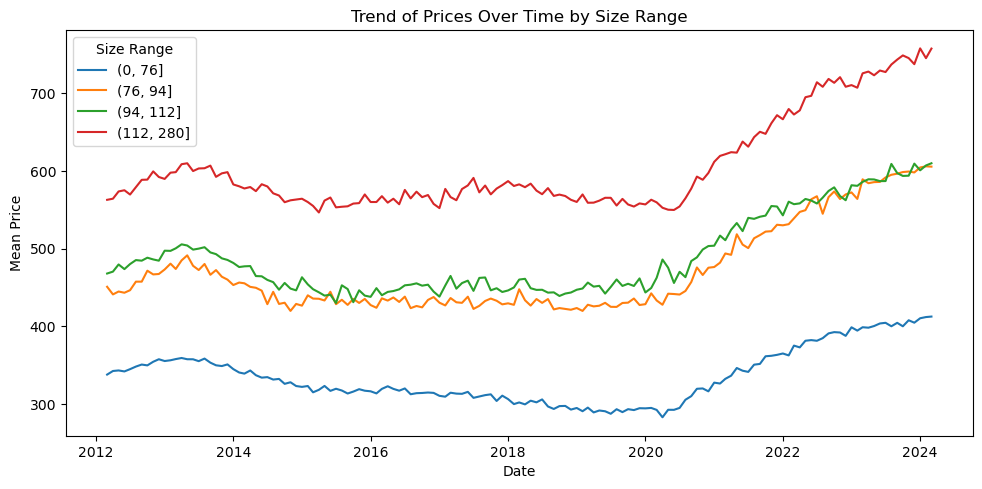

```python
dfs.sort_values('month_dt', inplace=True)
# Define bins for different ranges of sizes
bins = [0, 76, 94, 112, 280]  # Adjust these values as needed

# Create a new column for the size range
dfs['size_range'] = pd.cut(dfs['floor_area_sqm'], bins)

# Group by size range and month, then calculate the mean resale price
grouped = dfs.groupby(['size_range', 'month_dt'], observed=True)['resale_price_thousand'].mean().reset_index()

# Plot the mean resale price over time for each size range
for size_range in grouped['size_range'].unique():
    subset = grouped[grouped['size_range'] == size_range]
    plt.plot(subset['month_dt'], subset['resale_price_thousand'], label=str(size_range))

plt.title('Trend of Prices Over Time by Size Range')
plt.xlabel('Date')
plt.ylabel('Mean Price')
plt.legend(title='Size Range')
plt.show()
```

From these plots, we can observe the following:

- The real estate market has seen an overall increase in prices from 2012 to 2024, with larger flats experiencing a more substantial rise. This suggests a sustained demand for larger properties, or a market perception of greater value in larger units.
- Investors might consider focusing on larger properties for potentially higher returns.

### Town affect on resale price over time

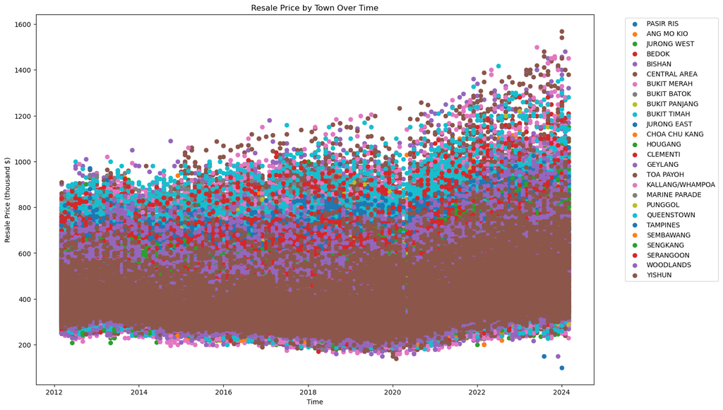

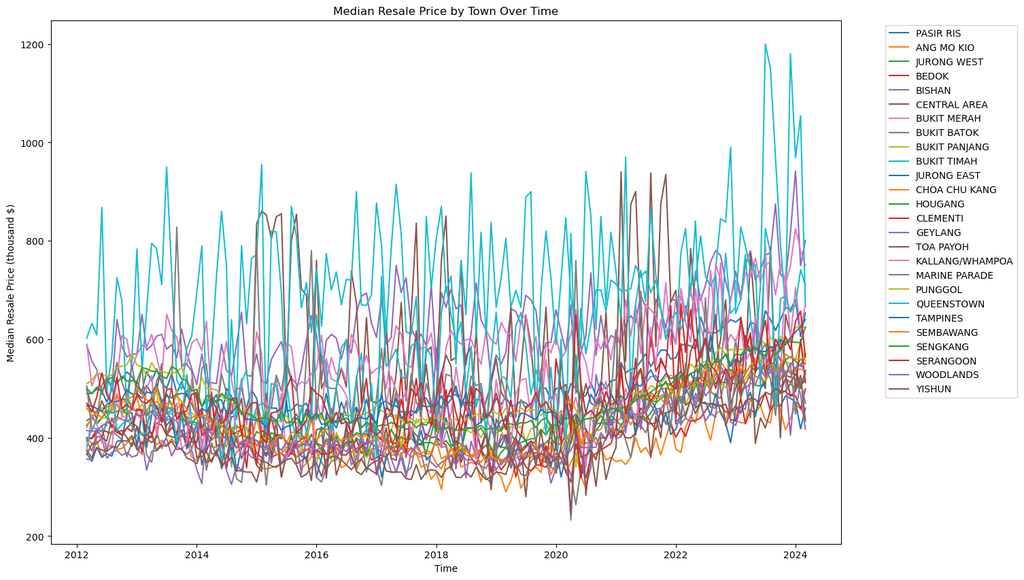

```python
# Create a list of unique towns
towns = dfs['town'].unique()

# Create a scatter plot of resale prices over time for each town
plt.figure(figsize=(15, 10))
for town in towns:
    town_data = dfs[dfs['town'] == town]
    plt.scatter(town_data['month_dt'], town_data['resale_price_thousand'], label=town)

plt.title('Resale Price by Town Over Time')
plt.xlabel('Time')
plt.ylabel('Resale Price (thousand $)')
plt.legend(bbox_to_anchor=(1.05, 1), loc='upper left')  # Place the legend outside the plot
plt.show()

# Grouping town data by month and taking the median to plot
town_medians = dfs.groupby(['town', 'month_dt'], as_index=False)[['resale_price_thousand']].median()
# Create a line plot of median resale prices over time for each town
plt.figure(figsize=(15, 10))
for town in towns:
    town_data = town_medians[town_medians['town'] == town]
    plt.plot(town_data['month_dt'], town_data['resale_price_thousand'], label=town)

plt.title('Median Resale Price by Town Over Time')
plt.xlabel('Time')
plt.ylabel('Median Resale Price (thousand $)')
plt.legend(bbox_to_anchor=(1.05, 1), loc='upper left')  # Place the legend outside the plot
plt.show()
```

The following can be observed:

- The provided visualizations reveal a market with increasing median housing prices over a 12-year span, marked by variability both within and across different towns.
- The data suggests that certain areas may be experiencing greater price appreciation, possibly reflecting their desirability or other positive attributes.

### Investigating `flat_type`'s effect on resale price

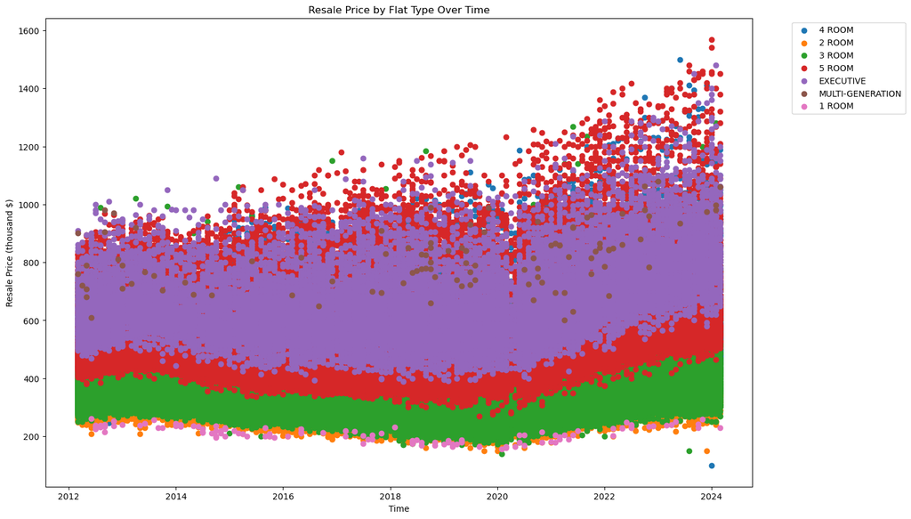

```python
# Get unique flat types
flat_types = dfs['flat_type'].unique()

# Create a scatter plot of resale prices over time for each flat type
plt.figure(figsize=(15, 10))
for flat_type in flat_types:
    flat_type_data = dfs[dfs['flat_type'] == flat_type]
    plt.scatter(flat_type_data['month_dt'], flat_type_data['resale_price_thousand'], label=flat_type)

plt.title('Resale Price by Flat Type Over Time')
plt.xlabel('Time')
plt.ylabel('Resale Price (thousand $)')
plt.legend(bbox_to_anchor=(1.05, 1), loc='upper left')  # Place the legend outside the plot
plt.show()
```

From the above, we can observe:

- There is a clear stratification of resale prices based on flat types, with larger flats generally selling for more than smaller ones
- The data indicates a general increase in resale prices over the observed period for all flat types across time
- Despite the general increase, there's considerable variability within each flat type category, implying that other factors also play a significant role in determining resale prices

We can also view the distribution of `flat_model` and `storey_range`'s, `flat_type`'s and `town` in our dataset:

```
Count of flat_model
flat_model
Model A                   86288
Improved                  66401
New Generation            37718
Premium Apartment         27913
Simplified                11712
Apartment                 10122
Standard                   8132
Maisonette                 7475
Model A2                   3384
DBSS                       3245
Model A-Maisonette          459
Adjoined flat               442
Type S1                     431
Type S2                     215
Terrace                     151
Premium Apartment Loft      107
Multi Generation            103
2-room                       85
Improved-Maisonette          35
3Gen                         28
Premium Maisonette           20
Name: count, dtype: int64
```

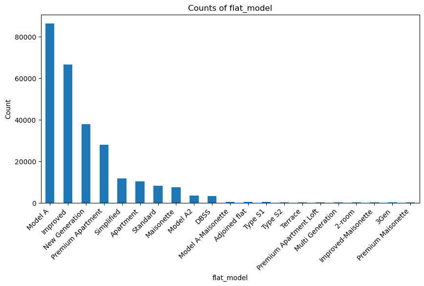

```
Count of flat_type
flat_type
4 ROOM              109186
3 ROOM               66754
5 ROOM               64216
EXECUTIVE            20116
2 ROOM                3972
1 ROOM                 119
MULTI-GENERATION       103
Name: count, dtype: int64
```

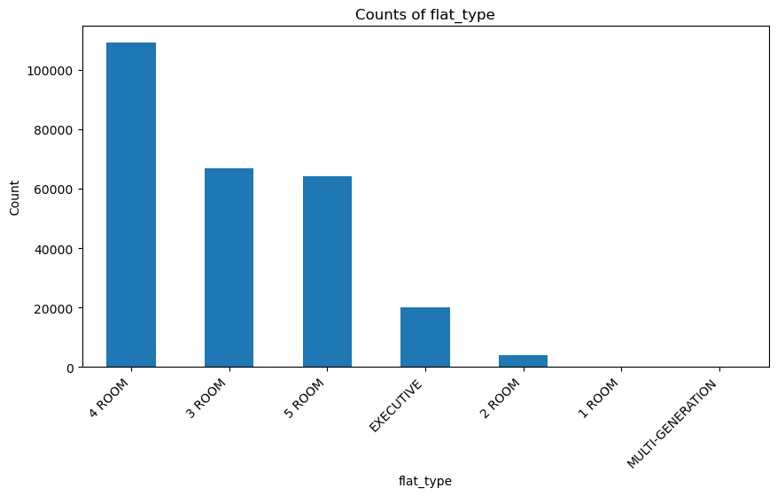

```
Count of town
town
SENGKANG           20288
WOODLANDS          19513
JURONG WEST        18834
TAMPINES           18159
YISHUN             17754
PUNGGOL            16022
BEDOK              15187
HOUGANG            13387
CHOA CHU KANG      11791
ANG MO KIO         11644
BUKIT MERAH        10212
BUKIT BATOK        10182
BUKIT PANJANG       9612
TOA PAYOH           8312
PASIR RIS           8198
KALLANG/WHAMPOA     7912
QUEENSTOWN          7296
SEMBAWANG           6985
GEYLANG             6851
CLEMENTI            6194
JURONG EAST         5655
SERANGOON           5168
BISHAN              4818
CENTRAL AREA        2148
MARINE PARADE       1713
BUKIT TIMAH          631
Name: count, dtype: int64
```

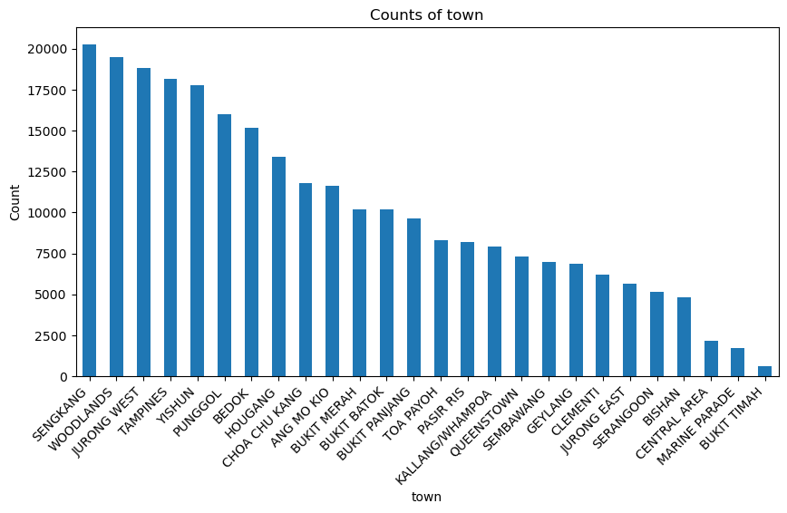

```
Count of storey_range
storey_range
04 TO 06    60711
07 TO 09    54827
10 TO 12    48159
01 TO 03    47574
13 TO 15    23247
16 TO 18    10500
19 TO 21     4486
22 TO 24     3144
01 TO 05     2700
06 TO 10     2474
25 TO 27     1829
11 TO 15     1259
28 TO 30     1184
31 TO 33      582
34 TO 36      546
37 TO 39      477
16 TO 20      265
40 TO 42      232
21 TO 25       92
43 TO 45       64
46 TO 48       49
26 TO 30       39
49 TO 51       17
36 TO 40        7
31 TO 35        2
Name: count, dtype: int64
```

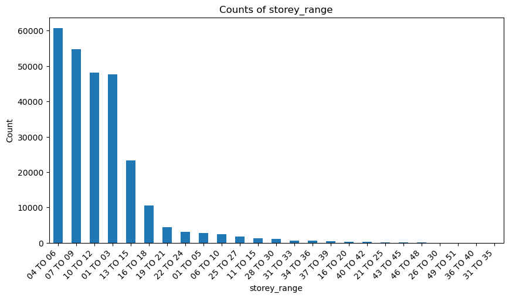

```python
categorical_variables = [
    'flat_model',
    'flat_type',
    'town',
    'storey_range'
]
for col in categorical_variables:
    counts = dfs[col].value_counts()
    # Columnar text counts for reference
    print(f'Count of {col}')
    print(counts, end='')

    counts = dfs[col].value_counts()
    counts.plot(kind='bar', figsize=(10, 5))
    plt.title(f'Counts of {col}')
    plt.xlabel(col)
    plt.xticks(rotation=45, ha='right')
    plt.ylabel('Count')
    plt.show()
```

For a general overview, the following is a interactive visualisation of the distribution and affect of housing price over time:

```python
%%html
<div class='tableauPlaceholder' id='viz1710941321740' style='position: relative'><noscript><a href='#'><img alt='Dashboard 1 ' src='https:&#47;&#47;public.tableau.com&#47;static&#47;images&#47;Si&#47;SingaporeAverageResalePrice&#47;Dashboard1&#47;1_rss.png' style='border: none' /></a></noscript><object class='tableauViz'  style='display:none;'><param name='host_url' value='https%3A%2F%2Fpublic.tableau.com%2F' /> <param name='embed_code_version' value='3' /> <param name='site_root' value='' /><param name='name' value='SingaporeAverageResalePrice&#47;Dashboard1' /><param name='tabs' value='no' /><param name='toolbar' value='yes' /><param name='static_image' value='https:&#47;&#47;public.tableau.com&#47;static&#47;images&#47;Si&#47;SingaporeAverageResalePrice&#47;Dashboard1&#47;1.png' /> <param name='animate_transition' value='yes' /><param name='display_static_image' value='yes' /><param name='display_spinner' value='yes' /><param name='display_overlay' value='yes' /><param name='display_count' value='yes' /><param name='language' value='en-GB' /><param name='filter' value='publish=yes' /></object></div>                <script type='text/javascript'>                    var divElement = document.getElementById('viz1710941321740');                    var vizElement = divElement.getElementsByTagName('object')[0];                    if ( divElement.offsetWidth > 800 ) { vizElement.style.width='100%';vizElement.style.height=(divElement.offsetWidth*0.75)+'px';} else if ( divElement.offsetWidth > 500 ) { vizElement.style.width='100%';vizElement.style.height=(divElement.offsetWidth*0.75)+'px';} else { vizElement.style.width='100%';vizElement.style.height='1027px';}                     var scriptElement = document.createElement('script');                    scriptElement.src = 'https://public.tableau.com/javascripts/api/viz_v1.js';vizElement.parentNode.insertBefore(scriptElement, vizElement);</script>
```

[figure not shown]

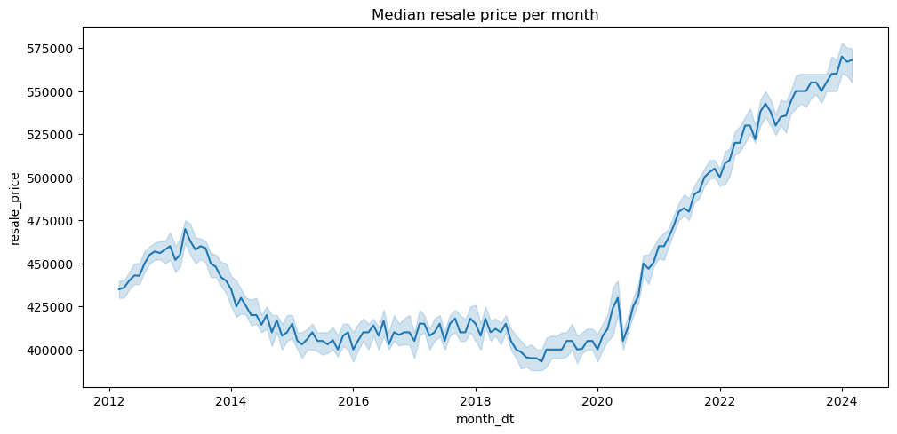

```python
ax = sns.lineplot(dfs, x='month_dt', y='resale_price', errorbar=('ci', 95), estimator='median')
ax.set_title('Median resale price per month')
plt.show()
```

```python
numeric_cols = dfs.select_dtypes(include='number')
print(numeric_cols.columns)
```

```
Index(['floor_area_sqm', 'lease_commence_date', 'resale_price', 'lease_left',
       'resale_price_thousand'],
      dtype='object')
```

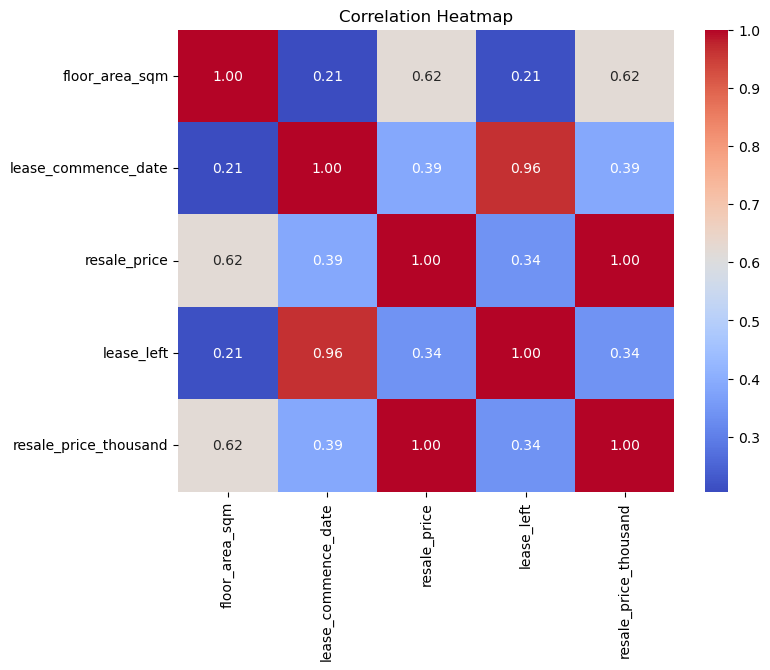

```python
#plotting heatmap for numeric variables
numeric_cols = dfs.select_dtypes(include='number')
corr_matrix = numeric_cols.corr()
plt.figure(figsize=(8, 6))
sns.heatmap(corr_matrix, annot=True, cmap='coolwarm', fmt=".2f")
plt.title('Correlation Heatmap')
plt.show()
```

From this correlation heatmap of numeric attributes we can tell that lease_left and lease_commence_date are highly correlated with a correlation value of 0.96, followed by resale_price and floor_area_sqm at 0.62, lease_commence_date and resale_price at 0.39, lease_left and resale_price_thousand at 0.34, and lease_left and floor_area_sqm at 0.21.

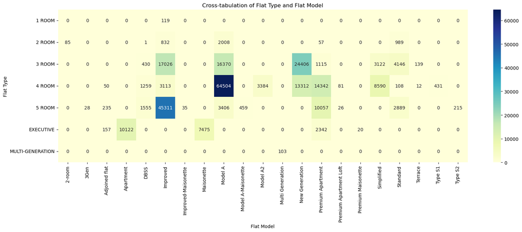

```python
plt.figure(figsize=(20, 6))
sns.heatmap(cross_tab, annot=True, cmap='YlGnBu', fmt='d')
plt.title('Cross-tabulation of Flat Type and Flat Model')
plt.xlabel('Flat Model')
plt.ylabel('Flat Type')
plt.show()
```

This correlation graph depicts the frequency of occurence between the various Flat Model and Flat Type. Flat Model Model A has the highest frequency of 4 Rooms, followed by Improved Flat Model with 5 Rooms. Thirdly new-generation flat models then to be 3 rooms. Within the period of 1976 to 1989, 3 room flats were initated with the New Generation model thus just as seen in the coreelation heat map, a high frequency of new generation models are 3 rooms.

# Task 5: Modeling and visualization

## Objective 1: Identify Location and Room-Type with Highest Investment Return

We can model and see what would be the best investment return for a location and room type by seeing what the lowest and highest median value for a flat type for a given month is (by location), and the ranking them based on this difference

```python
# With this, we get the median resale price per month for each flat_type in each town
grouped_town_flat = dfs.groupby(['town', 'month_dt', 'flat_type'], as_index=False)[['resale_price_thousand']].median()
```

```python
# Thereafter we sort by town, flat_type, and hence most importantly price and get the first and last entries representing
# the lowest median price and highest median price for a given month
grouped_town_flat_month_median = grouped_town_flat.sort_values(['town', 'flat_type', 'resale_price_thousand'])\
                                    .groupby(['town', 'flat_type'])\
                                        .agg(['first', 'last'])
grouped_town_flat_month_median
```

| town | flat_type | month_dt first | month_dt last | resale_price_thousand first | resale_price_thousand last |
| --- | --- | --- | --- | --- | --- |
| ANG MO KIO | 2 ROOM | 2019-09-01 | 2023-02-01 | 178.0 | 310.944 |
|  | 3 ROOM | 2019-05-01 | 2024-02-01 | 265.0 | 403.000 |
|  | 4 ROOM | 2020-05-01 | 2023-01-01 | 380.0 | 735.000 |
|  | 5 ROOM | 2020-04-01 | 2024-01-01 | 525.0 | 992.944 |
|  | EXECUTIVE | 2018-01-01 | 2023-09-01 | 660.0 | 1180.000 |
| ... | ... | ... | ... | ... | ... |
| YISHUN | 3 ROOM | 2020-05-01 | 2024-02-01 | 250.0 | 409.888 |
|  | 4 ROOM | 2018-02-01 | 2024-03-01 | 325.0 | 542.000 |
|  | 5 ROOM | 2018-02-01 | 2023-12-01 | 410.0 | 678.000 |
|  | EXECUTIVE | 2017-10-01 | 2022-10-01 | 499.0 | 875.400 |
|  | MULTI-GENERATION | 2016-09-01 | 2023-01-01 | 650.0 | 1080.000 |

131 rows × 4 columns

```python
# lets rename the columns
grouped_town_flat_month_median.reset_index(inplace=True)
grouped_town_flat_month_median.columns = ['town',
                                          'flat_type',
                                          'month_min',
                                          'month_max',
                                          'resale_price_thousand_min',
                                          'resale_price_thousand_max']
grouped_town_flat_month_median
```

|  | town | flat_type | month_min | month_max | resale_price_thousand_min | resale_price_thousand_max |
| --- | --- | --- | --- | --- | --- | --- |
| 0 | ANG MO KIO | 2 ROOM | 2019-09-01 | 2023-02-01 | 178.0 | 310.944 |
| 1 | ANG MO KIO | 3 ROOM | 2019-05-01 | 2024-02-01 | 265.0 | 403.000 |
| 2 | ANG MO KIO | 4 ROOM | 2020-05-01 | 2023-01-01 | 380.0 | 735.000 |
| 3 | ANG MO KIO | 5 ROOM | 2020-04-01 | 2024-01-01 | 525.0 | 992.944 |
| 4 | ANG MO KIO | EXECUTIVE | 2018-01-01 | 2023-09-01 | 660.0 | 1180.000 |
| ... | ... | ... | ... | ... | ... | ... |
| 126 | YISHUN | 3 ROOM | 2020-05-01 | 2024-02-01 | 250.0 | 409.888 |
| 127 | YISHUN | 4 ROOM | 2018-02-01 | 2024-03-01 | 325.0 | 542.000 |
| 128 | YISHUN | 5 ROOM | 2018-02-01 | 2023-12-01 | 410.0 | 678.000 |
| 129 | YISHUN | EXECUTIVE | 2017-10-01 | 2022-10-01 | 499.0 | 875.400 |
| 130 | YISHUN | MULTI-GENERATION | 2016-09-01 | 2023-01-01 | 650.0 | 1080.000 |

131 rows × 6 columns

From the following, we can use it to calculate Returns on investment (ROI) defined as:

$\text{ROI} = \frac{\text{Final value of investment} - \text{Initial value of investment}}{\text{Cost of investment}} \times 100\%$

Where in this case, as we are are finding the highest hypothetical return, would be where someone had the opportunity to buy low and sell high; becomes the following:

$\text{ROI} = \frac{\text{resale\_price\_thousand\_max - resale\_price\_thousand\_min}}{\text{resale\_price\_thousand\_min}} \times 100\%$

```python
# Calculating ROI
grouped_town_flat_month_median['median_roi'] = ((grouped_town_flat_month_median['resale_price_thousand_max'] - \
                                            grouped_town_flat_month_median['resale_price_thousand_min']) / \
                                            grouped_town_flat_month_median['resale_price_thousand_min']) * 100
```

```python
top_50 = grouped_town_flat_month_median.sort_values(by=['median_roi'], ascending=False).head(50)
top_50
```

|  | town | flat_type | month_min | month_max | resale_price_thousand_min | resale_price_thousand_max | median_roi |
| --- | --- | --- | --- | --- | --- | --- | --- |
| 21 | BUKIT MERAH | 2 ROOM | 2020-05-01 | 2024-02-01 | 170.000 | 523.000 | 207.647059 |
| 37 | CENTRAL AREA | 4 ROOM | 2014-08-01 | 2023-08-01 | 420.000 | 1200.000 | 185.714286 |
| 80 | PASIR RIS | 3 ROOM | 2019-10-01 | 2023-12-01 | 215.000 | 610.000 | 183.720930 |
| 38 | CENTRAL AREA | 5 ROOM | 2012-03-01 | 2023-10-01 | 575.500 | 1438.888 | 150.023979 |
| 45 | CLEMENTI | 2 ROOM | 2019-06-01 | 2023-05-01 | 205.000 | 492.000 | 140.000000 |
| 89 | QUEENSTOWN | 2 ROOM | 2018-11-01 | 2023-12-01 | 185.000 | 431.500 | 133.243243 |
| 48 | CLEMENTI | 5 ROOM | 2018-01-01 | 2024-01-01 | 526.000 | 1180.000 | 124.334601 |
| 35 | CENTRAL AREA | 2 ROOM | 2020-06-01 | 2023-06-01 | 200.000 | 430.000 | 115.000000 |
| 47 | CLEMENTI | 4 ROOM | 2019-04-01 | 2024-02-01 | 418.000 | 870.000 | 108.133971 |
| 52 | GEYLANG | 4 ROOM | 2014-08-01 | 2023-10-01 | 377.000 | 770.000 | 104.244032 |
| 64 | JURONG EAST | EXECUTIVE | 2017-01-01 | 2023-09-01 | 500.000 | 1020.000 | 104.000000 |
| 117 | TOA PAYOH | 4 ROOM | 2015-04-01 | 2022-10-01 | 415.000 | 844.444 | 103.480482 |
| 10 | BISHAN | 3 ROOM | 2016-01-01 | 2023-08-01 | 260.000 | 520.000 | 100.000000 |
| 5 | BEDOK | 2 ROOM | 2019-12-01 | 2023-07-01 | 180.000 | 355.000 | 97.222222 |
| 120 | WOODLANDS | 2 ROOM | 2018-11-01 | 2024-02-01 | 180.000 | 355.000 | 97.222222 |
| 2 | ANG MO KIO | 4 ROOM | 2020-05-01 | 2023-01-01 | 380.000 | 735.000 | 93.421053 |
| 121 | WOODLANDS | 3 ROOM | 2020-04-01 | 2024-02-01 | 223.000 | 430.000 | 92.825112 |
| 50 | GEYLANG | 2 ROOM | 2019-10-01 | 2023-10-01 | 150.000 | 287.944 | 91.962667 |
| 107 | SERANGOON | 5 ROOM | 2016-03-01 | 2024-01-01 | 455.888 | 871.000 | 91.055698 |
| 22 | BUKIT MERAH | 3 ROOM | 2020-04-01 | 2022-02-01 | 283.500 | 540.000 | 90.476190 |
| 3 | ANG MO KIO | 5 ROOM | 2020-04-01 | 2024-01-01 | 525.000 | 992.944 | 89.132190 |
| 65 | JURONG WEST | 2 ROOM | 2018-12-01 | 2023-03-01 | 192.000 | 360.000 | 87.500000 |
| 118 | TOA PAYOH | 5 ROOM | 2020-02-01 | 2024-03-01 | 550.000 | 1026.944 | 86.717091 |
| 9 | BEDOK | EXECUTIVE | 2019-06-01 | 2024-03-01 | 590.000 | 1100.000 | 86.440678 |
| 30 | BUKIT PANJANG | EXECUTIVE | 2016-07-01 | 2023-03-01 | 450.000 | 838.000 | 86.222222 |
| 119 | TOA PAYOH | EXECUTIVE | 2019-07-01 | 2024-02-01 | 600.000 | 1114.444 | 85.740667 |
| 73 | KALLANG/WHAMPOA | 5 ROOM | 2020-05-01 | 2023-08-01 | 523.500 | 970.000 | 85.291309 |
| 18 | BUKIT BATOK | 5 ROOM | 2019-11-01 | 2022-06-01 | 470.000 | 865.000 | 84.042553 |
| 53 | GEYLANG | 5 ROOM | 2020-01-01 | 2018-07-01 | 500.000 | 920.000 | 84.000000 |
| 71 | KALLANG/WHAMPOA | 3 ROOM | 2020-04-01 | 2024-03-01 | 244.000 | 448.000 | 83.606557 |
| 55 | HOUGANG | 2 ROOM | 2019-08-01 | 2024-02-01 | 205.000 | 375.000 | 82.926829 |
| 17 | BUKIT BATOK | 4 ROOM | 2020-04-01 | 2023-06-01 | 332.000 | 603.500 | 81.777108 |
| 105 | SERANGOON | 3 ROOM | 2019-09-01 | 2023-09-01 | 255.000 | 463.000 | 81.568627 |
| 34 | BUKIT TIMAH | EXECUTIVE | 2012-03-01 | 2023-12-01 | 745.000 | 1350.000 | 81.208054 |
| 32 | BUKIT TIMAH | 4 ROOM | 2012-07-01 | 2023-11-01 | 495.000 | 890.000 | 79.797980 |
| 4 | ANG MO KIO | EXECUTIVE | 2018-01-01 | 2023-09-01 | 660.000 | 1180.000 | 78.787879 |
| 108 | SERANGOON | EXECUTIVE | 2015-02-01 | 2022-10-01 | 607.000 | 1085.000 | 78.747941 |
| 19 | BUKIT BATOK | EXECUTIVE | 2015-01-01 | 2023-05-01 | 535.000 | 954.000 | 78.317757 |
| 96 | SEMBAWANG | 4 ROOM | 2020-04-01 | 2023-11-01 | 320.000 | 570.000 | 78.125000 |
| 97 | SEMBAWANG | 5 ROOM | 2018-03-01 | 2023-12-01 | 370.000 | 650.000 | 75.675676 |
| 129 | YISHUN | EXECUTIVE | 2017-10-01 | 2022-10-01 | 499.000 | 875.400 | 75.430862 |
| 98 | SEMBAWANG | EXECUTIVE | 2018-03-01 | 2023-07-01 | 448.888 | 786.000 | 75.099357 |
| 74 | KALLANG/WHAMPOA | EXECUTIVE | 2019-11-01 | 2023-03-01 | 655.000 | 1146.000 | 74.961832 |
| 72 | KALLANG/WHAMPOA | 4 ROOM | 2014-10-01 | 2022-02-01 | 480.000 | 839.000 | 74.791667 |
| 0 | ANG MO KIO | 2 ROOM | 2019-09-01 | 2023-02-01 | 178.000 | 310.944 | 74.687640 |
| 87 | PUNGGOL | 5 ROOM | 2018-06-01 | 2024-01-01 | 424.000 | 740.000 | 74.528302 |
| 114 | TAMPINES | MULTI-GENERATION | 2012-06-01 | 2024-03-01 | 610.000 | 1060.000 | 73.770492 |
| 124 | WOODLANDS | EXECUTIVE | 2016-09-01 | 2024-03-01 | 530.000 | 915.000 | 72.641509 |
| 41 | CHOA CHU KANG | 3 ROOM | 2017-03-01 | 2024-03-01 | 250.000 | 430.000 | 72.000000 |
| 13 | BISHAN | EXECUTIVE | 2013-09-01 | 2024-02-01 | 755.000 | 1295.000 | 71.523179 |

```python
print(top_50['flat_type'].value_counts())
print()
print(top_50['town'].value_counts())
```

```
flat_type
EXECUTIVE           13
2 ROOM              10
5 ROOM              10
4 ROOM               9
3 ROOM               7
MULTI-GENERATION     1
Name: count, dtype: int64

town
ANG MO KIO         4
KALLANG/WHAMPOA    4
SERANGOON          3
SEMBAWANG          3
CLEMENTI           3
GEYLANG            3
BUKIT BATOK        3
TOA PAYOH          3
CENTRAL AREA       3
WOODLANDS          3
BUKIT TIMAH        2
BUKIT MERAH        2
BEDOK              2
BISHAN             2
JURONG WEST        1
BUKIT PANJANG      1
JURONG EAST        1
HOUGANG            1
QUEENSTOWN         1
PASIR RIS          1
YISHUN             1
PUNGGOL            1
TAMPINES           1
CHOA CHU KANG      1
Name: count, dtype: int64
```

From the above, we can observe within the top 50 median resale prices over time:

- Ang Mo Kio and KALLANG/WHAMPOA represented one of the highest towns for investing, as they have more `flat_types` that had a high ROI
- Executive flats is represented with the highest ROI in terms of `flat_types` across many different towns (13 / 26 different towns are in the top 50)

## Objective 2-1: Using Linear Regression to Predict Future Price Growth

We can run the cleaned data through different models and evaluate the accuracy as well as derive insight from the machine learning models on how each variable affects resale price.

```python
import datetime

from sklearn.pipeline import Pipeline
from sklearn.preprocessing import StandardScaler, OneHotEncoder, OrdinalEncoder
from sklearn.linear_model import LinearRegression
from sklearn.compose import make_column_selector
from sklearn.compose import make_column_transformer
from sklearn.model_selection import train_test_split
```

```python
dfs['month_timestamp'] = dfs['month_dt'].apply(lambda x: x.timestamp()) # Add a column with the timestamp type derived from month_dt
```

```python
#Setting train columns
train_cols = [
    'month_timestamp',
    'town',
    'flat_type',
    'storey_range',
    'floor_area_sqm',
    'flat_model',
    'lease_commence_date',
    'lease_left'
]
```

```python
#split data with 25% test size
X_train, X_test, y_train, y_test = train_test_split(
    dfs[train_cols], dfs["resale_price"], test_size=0.25
)
```

```python
dfs['flat_type'].drop_duplicates().sort_values().to_list()
```

```
['1 ROOM',
 '2 ROOM',
 '3 ROOM',
 '4 ROOM',
 '5 ROOM',
 'EXECUTIVE',
 'MULTI-GENERATION']
```

Performing preprocessing with a pipeline

- The pipeline will automatically apply one-hot encoding to categorical variables such as `town`, `flat_model`, and `flat_type`. This is crucial because most machine learning algorithms require numerical input, and one-hot encoding converts categorical data into a numerical format that the model can process.
- The `storey_range` feature is transformed, which appears to be an ordinal categorical variable, is handled using OrdinalEncoder. This makes sense for data that has a specific order but is categorical in nature, preserving the inherent order in the encoded data.
- Numerical features are standardized using StandardScaler. Standardization adjusts the scale of the features so that they have a mean of 0 and a standard deviation of 1, improving the model's convergence and performance, especially in models sensitive to the scale of input features.
- The rest of the columns not explicitly mentioned in this pipeline should be dropped

```python
ct = make_column_transformer(
    (OneHotEncoder(), make_column_selector('town|flat_model|flat_type')),
    (OrdinalEncoder(), make_column_selector('storey_range')),
    (StandardScaler(), ["month_timestamp",
                        "floor_area_sqm",
                        "lease_commence_date",
                        "lease_left"]
)
, remainder='drop')
```

```python
linear_model = Pipeline([('Transform', ct),
                     ('linear', LinearRegression())])
```

```python
linear_model.fit(X_train, y=y_train)
```

```
Pipeline(steps=[('Transform',
                 ColumnTransformer(transformers=[('onehotencoder',
                                                  OneHotEncoder(),
                                                  <sklearn.compose._column_transformer.make_column_selector object at 0x29ff10f10>),
                                                 ('ordinalencoder',
                                                  OrdinalEncoder(),
                                                  <sklearn.compose._column_transformer.make_column_selector object at 0x29f9d5710>),
                                                 ('standardscaler',
                                                  StandardScaler(),
                                                  ['month_timestamp',
                                                   'floor_area_sqm',
                                                   'lease_commence_date',
                                                   'lease_left'])])),
                ('linear', LinearRegression())])
```

```python
print(f'The model accuracy based on test set is:\n{linear_model.score(X_test, y_test)}')
```

```
The model accuracy based on test set is:
0.8055388219962708
```

We can print and see the effect of each variable on the machine learning model to learn more about how it would affect resale price:

```python
print(f"Intercept: {linear_model.named_steps.linear.intercept_}")
for name, coef in zip(ct.get_feature_names_out(), linear_model.named_steps.linear.coef_):
    print(name.split('__')[1], coef)
```

```
Intercept: 552442.4865256477
town_ANG MO KIO 24145.19006270915
town_BEDOK 6343.040489015253
town_BISHAN 107049.73841819506
town_BUKIT BATOK -51285.1940711711
town_BUKIT MERAH 125162.71608107658
town_BUKIT PANJANG -111778.77398868426
town_BUKIT TIMAH 211397.92944389282
town_CENTRAL AREA 121231.28144623738
town_CHOA CHU KANG -137388.85469096608
town_CLEMENTI 53556.13351667099
town_GEYLANG 53786.20908263967
town_HOUGANG -51553.50809764263
town_JURONG EAST -45493.12094114989
town_JURONG WEST -102085.0163750079
town_KALLANG/WHAMPOA 76601.39643097368
town_MARINE PARADE 166330.71071766815
town_PASIR RIS -78486.06256151498
town_PUNGGOL -102567.88931778583
town_QUEENSTOWN 131261.98792356203
town_SEMBAWANG -143038.30029768802
town_SENGKANG -113538.93451732234
town_SERANGOON 20021.806986535074
town_TAMPINES -23024.416177623916
town_TOA PAYOH 71153.17907394841
town_WOODLANDS -126687.22619534955
town_YISHUN -81114.02244194182
flat_type_1 ROOM -58443.815860311
flat_type_2 ROOM -42968.6080323931
flat_type_3 ROOM -6080.904193554971
flat_type_4 ROOM 11428.906590744995
flat_type_5 ROOM 29454.964177548936
flat_type_EXECUTIVE 31532.301946357788
flat_type_MULTI-GENERATION 35077.15536924778
flat_model_2-room -80909.17282040267
flat_model_3Gen -22406.64976360343
flat_model_Adjoined flat -10320.608340827866
flat_model_Apartment -47268.21179390268
flat_model_DBSS 31139.144213632866
flat_model_Improved -89659.02760239068
flat_model_Improved-Maisonette 75381.82626857862
flat_model_Maisonette -9744.798986021884
flat_model_Model A -89072.50492808319
flat_model_Model A-Maisonette 24468.540961044033
flat_model_Model A2 -87814.0304090062
flat_model_Multi Generation 35077.15536924778
flat_model_New Generation -70174.53189083158
flat_model_Premium Apartment -77107.51442306179
flat_model_Premium Apartment Loft 40676.87950119784
flat_model_Premium Maisonette -14026.410491019367
flat_model_Simplified -70841.06060742107
flat_model_Standard -69757.81115464366
flat_model_Terrace 273850.1435344424
flat_model_Type S1 95727.46905580621
flat_model_Type S2 162781.17430815814
storey_range 8160.146052757824
month_timestamp 66191.77128336305
floor_area_sqm 87350.94397571636
lease_commence_date -109884.41647785863
lease_left 169661.32846521385
```

```python
from IPython.display import Markdown as md
feature_coeff_lookup = {k:v for k, v in zip(map(lambda x: x.split('__')[1], ct.get_feature_names_out()),
                                     linear_model.named_steps.linear.coef_)}
md(f"""
We can in use to to derive some understanding on how each variable affects the resale price.

First of all, we can use the intercept value to understand what is the general resale price, \\${linear_model.named_steps.linear.intercept_:.2f}
serves as the baseline for our model. Each factor impacts this model by the rate of their coefficient.

For example, lets look at `lease_left` which has a coefficient of \\${feature_coeff_lookup['lease_left']:.2f}. This means that for every year of lease
left, this impacts the resale price by this amount.

For boolean cases such as `town_BUKIT TIMAH`, where the coefficient is \\${feature_coeff_lookup['town_BUKIT TIMAH']:.2f}, this indicates
that if the town for the HDB is located in Bukit Timah (remember we had used OneHotEncoding, hence a maximum of only 1 of the towns can be 1),
the resale price increases by {feature_coeff_lookup['town_BUKIT TIMAH']:.2f}.

As we may expect, we can observe that due to the presence of a negative sign in front of the coefficients for `flat_type_1 ROOM`
and `lease_commence_date` negatively correlates to the price.

Using this, we can understand how different variables affect the resale price and by what amount.
""")
```

We can in use to to derive some understanding on how each variable affects the resale price.

First of all, we can use the intercept value to understand what is the general resale price, $552442.49 serves as the baseline for our model. Each factor impacts this model by the rate of their coefficient.

For boolean cases such as `town_BUKIT TIMAH`, where the coefficient is $211397.93, this indicates that if the town for the HDB is located in Bukit Timah (remember we had used OneHotEncoding, hence a maximum of only 1 of the towns can be 1), the resale price increases by 211397.93.

As we may expect, we can observe that due to the presence of a negative sign in front of the coefficients for `flat_type_1 ROOM` and `lease_commence_date` negatively correlates to the price.

Using this, we can understand how different variables affect the resale price and by what amount.

```python
print('This timestamp will be used as time now', timenow:= datetime.datetime.now().timestamp())
```

```
This timestamp will be used as time now 1713868538.204295
```

```python
l_prediction = linear_model.predict(pd.DataFrame(
    {
        'month_timestamp': timenow,
        'town': 'CLEMENTI',
        'flat_type': '3 ROOM',
        'storey_range': '01 TO 05',
        'floor_area_sqm': 121.0,
        'flat_model': 'Standard',
        'lease_commence_date': 2012,
        'lease_left': 87.8
    },
    index=[0]
))
```

```python
print(f'The predicted resale price for the given parameters is: ${round(l_prediction[0])} SGD')
```

```
The predicted resale price for the given parameters is: $753675 SGD
```

## Objective 2-2: Using Machine Learning to Predict Future Price Growth

We can also run the cleaned data through different models and evaluate the accuracy as well as derive insight from the machine learning models on how each variable affects resale price.

```python
import datetime
import numpy as np
from sklearn.compose import make_column_transformer
from sklearn.preprocessing import FunctionTransformer
from sklearn.pipeline import Pipeline
from sklearn.preprocessing import StandardScaler, OneHotEncoder, OrdinalEncoder
from sklearn.compose import make_column_selector
from sklearn.model_selection import train_test_split
# HistGradientBoostingRegressor was found to yield a higher accuracy than GradientBoostingRegressor
from sklearn.ensemble import HistGradientBoostingRegressor
```

```python
dfs.sample(5)
```

|  | town | flat_type | storey_range | floor_area_sqm | flat_model | lease_commence_date | resale_price | year | months | lease_left | month_dt | resale_price_thousand | size_range | month_timestamp |
| --- | --- | --- | --- | --- | --- | --- | --- | --- | --- | --- | --- | --- | --- | --- |
| 73134 | TAMPINES | 3 ROOM | 10 TO 12 | 74.0 | Model A | 1985 | 315000.0 | 68 | 0 | 68.000000 | 2016-03-01 | 315.0 | (0, 76] | 1.456790e+09 |
| 231339 | YISHUN | 4 ROOM | 04 TO 06 | 84.0 | Simplified | 1988 | 395000.0 | 64 | 10 | 64.833333 | 2022-12-01 | 395.0 | (76, 94] | 1.669853e+09 |
| 237651 | PUNGGOL | 5 ROOM | 07 TO 09 | 113.0 | Premium Apartment | 2018 | 762000.0 | 94 | 05 | 94.416667 | 2023-03-01 | 762.0 | (112, 280] | 1.677629e+09 |
| 130846 | KALLANG/WHAMPOA | 4 ROOM | 07 TO 09 | 102.0 | Model A | 1998 | 595000.0 | 79 | 01 | 79.083333 | 2018-12-01 | 595.0 | (94, 112] | 1.543622e+09 |
| 218793 | KALLANG/WHAMPOA | 4 ROOM | 07 TO 09 | 84.0 | Simplified | 1987 | 552000.0 | 63 | 11 | 63.916667 | 2022-06-01 | 552.0 | (76, 94] | 1.654042e+09 |

```python
dfs['storey_range'].drop_duplicates().sort_values().to_list()
```

```
['01 TO 03',
 '01 TO 05',
 '04 TO 06',
 '06 TO 10',
 '07 TO 09',
 '10 TO 12',
 '11 TO 15',
 '13 TO 15',
 '16 TO 18',
 '16 TO 20',
 '19 TO 21',
 '21 TO 25',
 '22 TO 24',
 '25 TO 27',
 '26 TO 30',
 '28 TO 30',
 '31 TO 33',
 '31 TO 35',
 '34 TO 36',
 '36 TO 40',
 '37 TO 39',
 '40 TO 42',
 '43 TO 45',
 '46 TO 48',
 '49 TO 51']
```

Similar to preprocessing for linear regression, we perform preprocessing with a similar pipeline:

- The pipeline will automatically apply one-hot encoding to categorical variables such as `town`, `flat_model`, and `flat_type`. This is crucial because most machine learning algorithms (including gradient boosting methods) require numerical input, and one-hot encoding converts categorical data into a numerical format that the model can process.
- The `storey_range` feature is transformed, which appears to be an ordinal categorical variable, is handled using OrdinalEncoder. This makes sense for data that has a specific order but is categorical in nature, preserving the inherent order in the encoded data.
- Numerical features are standardized using StandardScaler (applied to the remaining columns not explicitly mentioned). Standardization adjusts the scale of the features so that they have a mean of 0 and a standard deviation of 1, improving the model's convergence and performance, especially in models sensitive to the scale of input features.

```python
#Creat the preprocess pipline
ct = make_column_transformer(
    (OneHotEncoder(), make_column_selector('town|flat_model|flat_type')),
    (OrdinalEncoder(), make_column_selector('storey_range'))
, remainder=StandardScaler())
```

```python
#fit the training data to the preprocess pipeline
ct.fit(X_train, y=y_train)
```

```
ColumnTransformer(remainder=StandardScaler(),
                  transformers=[('onehotencoder', OneHotEncoder(),
                                 <sklearn.compose._column_transformer.make_column_selector object at 0x2a0241ad0>),
                                ('ordinalencoder', OrdinalEncoder(),
                                 <sklearn.compose._column_transformer.make_column_selector object at 0x29f86ae50>)])
```

A function transformer is added to the pipline to handel all the features outputed from the encoder.

HistGradientBoostingRegressor (HGBR) is chosen for this task with following reasons:

- HGBR is capable of capturing complex non-linear relationships between the features and the target variable (resale price), which is common in real estate pricing.
- Real estate pricing often involves interactions between features (e.g., the impact of town on price may differ depending on the flat_type or lease_left). HGBR can automatically learn these interactions during the training process.
- The real estate market can have significant price outliers due to unique properties or market conditions. HGBR’s histogram-based approach makes it less sensitive to outliers than models that rely on individual data points.
- Given that HDB transactions constitute a large dataset, HGBR’s efficiency with large datasets ensures that the model can be trained and updated relatively quickly.

```python
#create transformer and HGBR in the pipline
model = Pipeline([('Transform', ct),
                     ('todense', FunctionTransformer(lambda x: np.array(x.todense()), accept_sparse=True)),
                     ('hgbr', HistGradientBoostingRegressor(loss='squared_error', random_state=5100))])
```

```python
#train model
model.fit(X_train, y=y_train)
```

```
Pipeline(steps=[('Transform',
                 ColumnTransformer(remainder=StandardScaler(),
                                   transformers=[('onehotencoder',
                                                  OneHotEncoder(),
                                                  <sklearn.compose._column_transformer.make_column_selector object at 0x2a0241ad0>),
                                                 ('ordinalencoder',
                                                  OrdinalEncoder(),
                                                  <sklearn.compose._column_transformer.make_column_selector object at 0x29f86ae50>)])),
                ('todense',
                 FunctionTransformer(accept_sparse=True,
                                     func=<function <lambda> at 0x2a18100e0>)),
                ('hgbr', HistGradientBoostingRegressor(random_state=5100))])
```

```python
#model accuracy
print(f'The model accuracy based on test set is:\n{model.score(X_test, y_test)}')
```

```
The model accuracy based on test set is:
0.9361501227518689
```

```python
#Performance analysis
from sklearn.metrics import r2_score, mean_absolute_error, mean_squared_error

# Assuming you have already predicted the test set using the HGBR model
y_pred = model.predict(X_test)

print("R-squared:", r2_score(y_test, y_pred))
print("Mean Absolute Error (MAE):", mean_absolute_error(y_test, y_pred))
print("Root Mean Squared Error (RMSE):", mean_squared_error(y_test, y_pred, squared=False))
```

```
R-squared: 0.9361501227518689
Mean Absolute Error (MAE): 29182.57212315949
Root Mean Squared Error (RMSE): 40088.61059956296
```

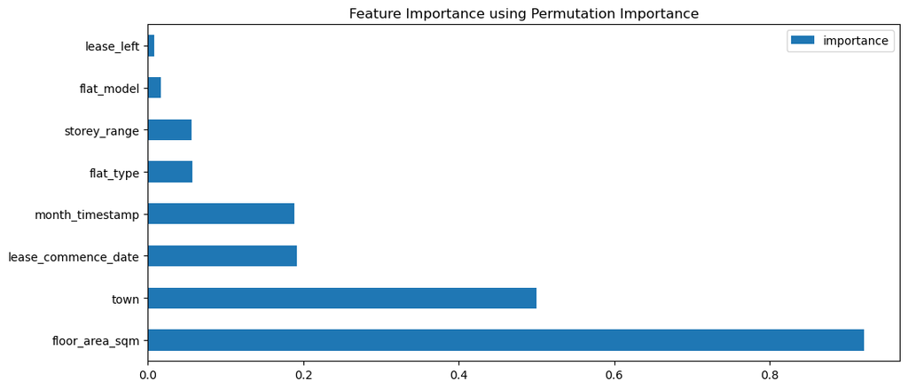

```python
#Feature importance analysis23
from sklearn.inspection import permutation_importance

# Compute permutation importance
perm_importance = permutation_importance(model, X_test, y_test)

# Organize as a DataFrame
feature_importances = pd.DataFrame(perm_importance.importances_mean, index=X_train.columns, columns=['importance']).sort_values('importance', ascending=False)

# Plot feature importances
feature_importances.head(10).plot(kind='barh')  # Top 10 features
plt.title('Feature Importance using Permutation Importance')
plt.show()
```

From the result it can be found that the features that affect the resale price most is floor area size and town, which are reasonable. The lease commence date and monthstamp has moderate affect on resale price. The lease commence date basically represent how old the property is, it is reasonable it has a quite strong effect on the resale price. The month timestamp is from month_dt, which is in the learning data when the property is sold, the affect of that on the resale price is due to the increasing tendency on the resale price since 2020.  
Storey range, flat type, flat model and lease left has low affect on the resale price, this may represent that the market is not care strongly on these features and therefore not as sensitive to changes in these variables.

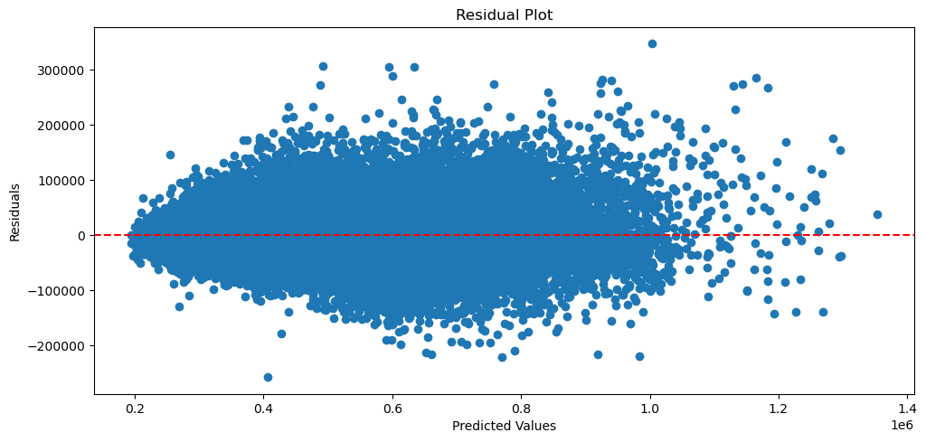

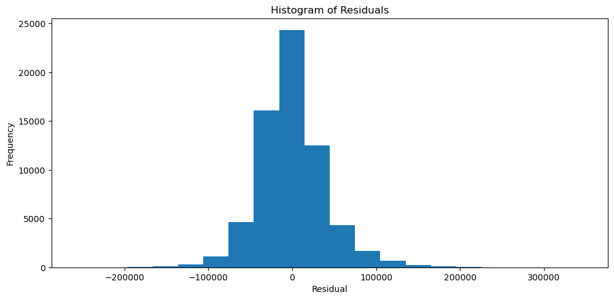

```python
#Residual Analysis
residuals = y_test - y_pred

# Residual Plot
plt.scatter(y_pred, residuals)
plt.title('Residual Plot')
plt.xlabel('Predicted Values')
plt.ylabel('Residuals')
plt.axhline(y=0, color='red', linestyle='--')
plt.show()

# Histogram of Residuals
plt.hist(residuals, bins=20)
plt.title('Histogram of Residuals')
plt.xlabel('Residual')
plt.ylabel('Frequency')
plt.show()
```

```python
# Compare training and test set performance
print("Training set score:", model.score(X_train, y_train))
print("Test set score:", model.score(X_test, y_test))
```

```
Training set score: 0.9381343433009135
Test set score: 0.9361501227518689
```

These scores suggest that the model is generalizing well to unseen data because there is only a small difference between its performance on the training data and the test data. Typically, overfitting is indicated when there's a significant gap between the training score and the test score, with the training score being much higher than the test score.

```python
set(dfs['flat_model'])
```

```
{'2-room',
 '3Gen',
 'Adjoined flat',
 'Apartment',
 'DBSS',
 'Improved',
 'Improved-Maisonette',
 'Maisonette',
 'Model A',
 'Model A-Maisonette',
 'Model A2',
 'Multi Generation',
 'New Generation',
 'Premium Apartment',
 'Premium Apartment Loft',
 'Premium Maisonette',
 'Simplified',
 'Standard',
 'Terrace',
 'Type S1',
 'Type S2'}
```

```python
print('This timestamp will be used as time now', timenow:= datetime.datetime.now().timestamp())
```

```
This timestamp will be used as time now 1713868548.536808
```

```python
prediction = model.predict(pd.DataFrame(
    {
        'month_timestamp': timenow,
        'town': 'CLEMENTI',
        'flat_type': '3 ROOM',
        'storey_range': '01 TO 05',
        'floor_area_sqm': 121.0,
        'flat_model': 'Standard',
        'lease_commence_date': 2012,
        'lease_left': 87.8
    },
    index=[0]
))
```

```python
print(f'The predicted resale price for the given parameters is: ${round(prediction[0])} SGD')
```

```
The predicted resale price for the given parameters is: $887235 SGD
```

# Task 6: Report insights and conclusions

To summarise, two main issues this project aims to answer are a. Identify Location and Room-Type with Highest Investment Return and b. Using Machine Learning to Predict Future Price Growth. We conclude that with our processes, approach used, and insights found as a result of our project that stakeholders can use data analysis and machine learning such as HGBR to make better informed decision before acting on a transaction price.

First, we identified the data required for this analysis. This is present and extracted in part Task 2: Data collection/curation. In Task 3: Data preparation, we have identified rows having null values for `remaining_lease` and imputed the values using the proxy column, `lease_commence_date`. In addition, we have performed preprocessing such as converting inconsistent text data (e.g. values `48 years`, `71`, `92 years 10 months` in `remaining_lease`) to ensure that the values are consistent as some columns have inconsistent inputs.

Then in Understanding the data, we explore the data to find the distribution of data available, as well as gather more information on patterns and and trends in our data. We saw that columns such as `town`, `flat_type` and month / time has a visible impact on resale price. In fact, one of the main findings is the positive relation between price and time, where we can observe that resale price has risen with time particularly after 2020. We then focus our efforts in answering the questions we have posed in our objectives.

Recalling the objectives:

> **Objective 1**: Identify Location and Room-Type with Highest Investment Return: This involves analyzing historical resale price data to determine which locations and types of rooms (e.g., 4-room, 5-room, etc.) have shown the highest return on investment over the past years. It aims to provide insights for potential property investors or homeowners looking to maximize their returns.

In section Objective 1: Identify Location and Room Type with Highest Investment Return, we calculated what would be the best investment return for a given location and room type. The median resale price is used here to mitigate the possibility that a single transaction brings up or down an average for a month due to being an anomaly. We therefore find the respective lowest and highest median value for a flat type for a given month is (by location), and the ranking them based on this difference. As result, we can conclude that for each of the following, the highest ROI was:

- For towns to invest in: Ang Mo Kio and Kallang/Whampoa represented one of the highest towns for investing as they have more flat_types that had a high ROI
- For types of rooms: Executive flats is represented with the highest ROI in terms of flat_types across many different towns (13 / 26 different towns are in the top 50)

> **Objective 2**: Using Machine Learning to Predict Future Price Growth: This objective involves building predictive models using machine learning algorithms on historical resale price data to forecast future price growth. By leveraging past trends and patterns, the goal is to provide stakeholders with insights into potential future price movements, aiding in decision-making processes related to property investment.

We have built 2 different machine learning models based on historical resale price for modelling and forecasting future resale price growth.  
First in Objective 2-1: Using Linear Regression to Predict Future Price Growth, we preprocessed the data we have using `OneHotEncoder`, `OrdinalEncoder` and `StandardScaler` to convert categorical variables into numbers and scaled some numeric variables to ensure that larger values create less bias in the model. Simultaneously, we selected columns that would make most sense in the model as the ones not used are dropped from the model training process. Using this, we were able to observe how each variable impacts the resale price by reviewing the coefficients of each variable of the final model. The outcome was a model that is about ~80% accurate predicting the resale price on the unseen test data, allowing us to use this model for predicting future price movements.

Then in Objective 2-2: Using Machine Learning to Predict Future Price Growth, similar to in linear regression modelling, we have preprocessed the data but have trained a ensemble learning machine learning model. The result is that the model was about ~93.6% accurate based on r2 score. We have also seen that `floor_area_sqm`, `town`, `lease_commence_date` and `month` (equivalent to time) had the highest impact on resale price in this model confirming what we have observed in the EDA process. The result is a potentially more accurate model for predicting the resale price.

Overall, the following insights can be found after analyzing historical resale data. Executive flats provide the highest ROI, and property in the Ang Mo Kio or Kallang/Whampoa area provide the highest ROI. Thus homeowners or potential property investors can zoom in on these locations and flat types for purchase. We have deployed two predictive models and the model which under statistical analysis prove to be a more accurate model, is HGBR. This model predicted that for a standard 3 room flat in clementi, with a floor sq area of 121, on the 1st to 5th storey, with a lease that started in 2012 and a lease of 87.8 left, resale is priced at $887235 SGD (as of 2024-04-23 18:35:48). With this knowledge, potential homeowners or property investors may weigh their options and choose which houses to purchase. Apart from historical data analysis and return of investment which we have used as a measurement of success for our models, positive user feedback from stakeholders who utilise insights generated by the data pipeline would indicate that the insights are actionable. All in all, the data pipeline built can be used to generate reports on the housing climate in Singapore, perform in-depth analysis of historical resale price data to uncover patterns for investment and predict housing prices for property investment strategies.